# Human Activity Recognition: Did you do it right?

FW TANG

20 March, 2015

### 1. Introduction

Todate, various devices can collect a lot of data on Human Activity Recognitio. However, people regularly do is quantify how much of a particular activity they do, but they rarely quantify how well they do it.

The goal of this project is to predict whether the activity is carried out correctly by using the data collected from accelerometers on the bel, forearm, arm, and dumbell of 6 participants where they were asked to perform barbell lifts correctly and incorrectly in 5 different ways. The “classe” field captures either “A”, “B”, “C”, “D” or “E”, where “A” indicates the correct way.

More information is available from the website here: http://groupware.les.inf.puc-rio.br/har

### 2. Data

The data for this project come from this source: http://groupware.les.inf.puc-rio.br/har.

The training data for this project are available here:

https://d396qusza40orc.cloudfront.net/predmachlearn/pml-training.csv

The test data are available here:

https://d396qusza40orc.cloudfront.net/predmachlearn/pml-testing.csv

#### 2.1 Data Preparation

Training data and testing data are downloaded, analysed and cleaned if necessary.

```r
train_url<-"https://d396qusza40orc.cloudfront.net/predmachlearn/pml-training.csv"
test_url<-"https://d396qusza40orc.cloudfront.net/predmachlearn/pml-testing.csv"

training<-read.csv(textConnection(getURL(train_url)), na.strings= c("NA", "", "#DIV/0!"))

testing<-read.csv(textConnection(getURL(test_url)), na.strings= c("NA", "", "#DIV/0!"))
```

Take a quick look at the data. May also explore the data using excel or other tools.

```r
summary(training)
```

[output not shown]

```r
summary(training$classe)
```

```
##    A    B    C    D    E
## 5580 3797 3422 3216 3607
```

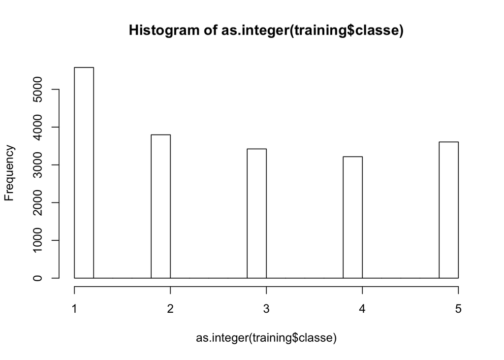

```r
hist(as.integer(training$classe))
```

```r
#Remove near zero variance using nearZeroVar from caret library
nzv_cols = nearZeroVar(training)
if(length(nzv_cols) > 0) training = training[, -nzv_cols]

testing = testing[, -nzv_cols]

training<-training[,colSums(is.na(training)) <= 0]
testing<-testing[,colSums(is.na(testing)) <= 0]

training<-training[,6:59]
testing<-testing[,6:59]
```

#### 2.2 Data Slicing - to get training and testing data set from downloaded training set to build the model. 60% of the downloaded training set will be used as the “training data” set to build the model.

```r
inTrain<-createDataPartition(y=training$classe,p=0.6,list=F)
intraining<-training[inTrain,]
intesting<-training[-inTrain,]
```

### 3. Build and Test the Model

```r
#set seed
set.seed(12345)

## set train control parameter, with cross validation and number of folds
control<-trainControl(method = "cv", number=10)
```

#### 3.2 Build models

Different models can be built to check the accuracy of the model, look for important variables and find the better model with good accuracy, moderate training time. Two methods are shown below.

```r
## do the following so that the training can be executed in parallel
library("cluster")
library("parallel")
library("doSNOW")
coreNumber=max(detectCores(),1)
cluster=makeCluster(coreNumber, type = "SOCK",outfile="")
registerDoSNOW(cluster)
```

```r
##build model using Stochastic Gradient Boosting
GBM = train(classe~.,data=intraining,method="gbm", trControl=control, verbose=F)

##build model using random forests
modFitRF = train(classe~., data=intraining, method = "rf", importance=T)
```

Both models show a high accuracy in training. We review the importance of variables in these two models.

```
## gbm variable importance
##
##   only 20 most important variables shown (out of 53)
##
##                   Overall
## num_window        100.000
## roll_belt          99.403
## pitch_forearm      51.443
## magnet_dumbbell_z  43.528
## yaw_belt           30.159
## magnet_dumbbell_y  26.743
## roll_forearm       17.221
## accel_forearm_x    14.600
## magnet_belt_z      13.933
## accel_dumbbell_z   13.306
## roll_dumbbell      12.377
## gyros_belt_z       10.073
## pitch_belt          9.554
## gyros_dumbbell_y    9.120
## accel_dumbbell_y    8.650
## magnet_forearm_z    8.617
## accel_dumbbell_x    7.564
## yaw_arm             4.916
## magnet_belt_y       4.053
## roll_arm            3.917
```

```
## Stochastic Gradient Boosting
##
## 11776 samples
##    53 predictor
##     5 classes: 'A', 'B', 'C', 'D', 'E'
##
## No pre-processing
## Resampling: Cross-Validated (10 fold)
##
## Summary of sample sizes: 10598, 10599, 10599, 10600, 10599, 10598, ...
##
## Resampling results across tuning parameters:
##
##   interaction.depth  n.trees  Accuracy   Kappa      Accuracy SD
##   1                   50      0.7601054  0.6956041  0.009106184
##   1                  100      0.8326256  0.7881721  0.012015602
##   1                  150      0.8749999  0.8418245  0.009565065
##   2                   50      0.8874828  0.8575359  0.009775196
##   2                  100      0.9434448  0.9284480  0.010999454
##   2                  150      0.9636553  0.9540153  0.007779319
##   3                   50      0.9306209  0.9121826  0.008374017
##   3                  100      0.9702774  0.9623929  0.006958736
##   3                  150      0.9852250  0.9813095  0.003922009
##   Kappa SD
##   0.011503637
##   0.015200804
##   0.012101068
##   0.012374363
##   0.013922058
##   0.009846146
##   0.010615920
##   0.008805228
##   0.004962400
##
## Tuning parameter 'shrinkage' was held constant at a value of 0.1
## Accuracy was used to select the optimal model using  the largest value.
## The final values used for the model were n.trees = 150,
##  interaction.depth = 3 and shrinkage = 0.1.
```

```
## rf variable importance
##
##   variables are sorted by maximum importance across the classes
##   only 20 most important variables shown (out of 53)
##
##                           A     B      C     D     E
## num_window           55.535 94.61 100.00 61.87 73.71
## roll_belt            66.923 85.51  70.25 73.00 78.54
## pitch_forearm        54.337 60.04  71.33 50.32 49.62
## magnet_dumbbell_z    63.621 51.68  61.75 49.53 45.04
## magnet_dumbbell_y    58.913 61.53  61.03 58.84 49.11
## yaw_belt             33.563 50.42  48.14 60.98 36.99
## pitch_belt           24.329 60.28  48.24 36.14 32.26
## roll_forearm         36.188 26.79  28.82 24.38 24.43
## gyros_dumbbell_y     34.145 22.84  26.86 18.71 12.55
## accel_forearm_x      12.029 26.17  20.96 32.09 28.88
## accel_dumbbell_y     25.589 22.54  30.32 22.54 24.79
## magnet_belt_z        13.139 24.43  17.45 27.82 20.79
## roll_dumbbell        17.038 26.33  20.64 26.30 27.29
## total_accel_dumbbell 11.122 23.51  16.17 24.32 23.14
## magnet_belt_x         8.765 23.74  20.57 16.70 20.02
## accel_dumbbell_z     13.162 22.02  20.58 22.69 23.28
## magnet_belt_y        13.347 23.27  20.74 18.85 19.33
## magnet_forearm_z     22.022 21.57  19.71 18.45 20.13
## yaw_dumbbell          9.018 21.51  11.71 15.78 14.02
## gyros_belt_z         11.379 20.76  18.11 15.47 19.77
```

```
## Random Forest
##
## 11776 samples
##    53 predictor
##     5 classes: 'A', 'B', 'C', 'D', 'E'
##
## No pre-processing
## Resampling: Bootstrapped (25 reps)
##
## Summary of sample sizes: 11776, 11776, 11776, 11776, 11776, 11776, ...
##
## Resampling results across tuning parameters:
##
##   mtry  Accuracy   Kappa      Accuracy SD  Kappa SD
##    2    0.9886787  0.9856837  0.002045765  0.002589669
##   27    0.9945690  0.9931337  0.001094503  0.001383545
##   53    0.9895343  0.9867700  0.004325177  0.005461235
##
## Accuracy was used to select the optimal model using  the largest value.
## The final value used for the model was mtry = 27.
```

It is observed that there are few variables of high importance for both models. Number of variables can be reduced and then train the models again. (This is not carried out as the accuracy is good without reducing the variables.)

#### 3.3 Cross validate the model using the “testing” data

Since both models are equally accurate, random forests model is applied with the cross validate “testing” data set.

```r
modTestRF<-predict(modFitRF, intesting)
confusionMatrix(modTestRF, intesting$classe)
```

```
## Confusion Matrix and Statistics
##
##           Reference
## Prediction    A    B    C    D    E
##          A 2232    7    0    0    0
##          B    0 1510    7    0    0
##          C    0    1 1361    8    0
##          D    0    0    0 1277    6
##          E    0    0    0    1 1436
##
## Overall Statistics
##
##                Accuracy : 0.9962
##                  95% CI : (0.9945, 0.9974)
##     No Information Rate : 0.2845
##     P-Value [Acc > NIR] : < 2.2e-16
##
##                   Kappa : 0.9952
##  Mcnemar's Test P-Value : NA
##
## Statistics by Class:
##
##                      Class: A Class: B Class: C Class: D Class: E
## Sensitivity            1.0000   0.9947   0.9949   0.9930   0.9958
## Specificity            0.9988   0.9989   0.9986   0.9991   0.9998
## Pos Pred Value         0.9969   0.9954   0.9934   0.9953   0.9993
## Neg Pred Value         1.0000   0.9987   0.9989   0.9986   0.9991
## Prevalence             0.2845   0.1935   0.1744   0.1639   0.1838
## Detection Rate         0.2845   0.1925   0.1735   0.1628   0.1830
## Detection Prevalence   0.2854   0.1933   0.1746   0.1635   0.1832
## Balanced Accuracy      0.9994   0.9968   0.9967   0.9960   0.9978
```

The out of sample accuracy is roughly 99%, which is good and ready for prediction assigment.

#### 4.0 Prediction Assignment

Apply the model to the assignment testing set.

```r
testing_anwRF<-predict(modFitRF, testing)
```

### 5.0 Conclusion

Non linear models are accurate but may take a longer time to train the model. Train control and more tuning may be necessary to improve the performance in training non linear models.